# Creative Gaming: Propensity-to-Buy Modeling

Generate prediction plots for each of these 5 features and summarize your findings (1 point)

The following plots seem to show the highest impact:

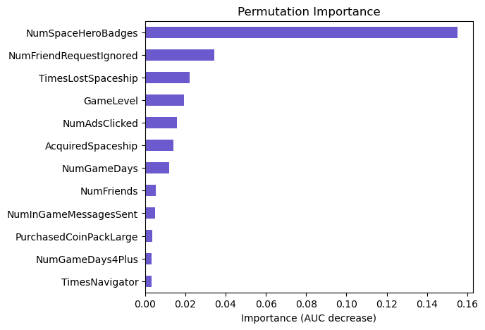

```python
lr.plot('vimp', data=train)
```

This Permutation Importance only supports the Logistic Regression test of excluding variables

What are the 5 most important features? (1 point)

```
-  The five most important features are:
    1.  NumSPaceHeroBadges
    2.  NumFriendRequestIgnored
    3.  TimesLostSpaceship
    4.  GameLevel
    5.  NumAdsClicked
```

```python
# Question 2.3
# Create a new variable “pred_logit” with predictions from the logistic regression
# model for all rows in the data (1 point)

cg_organic['pred_logit'] = lr.predict(cg_organic)['prediction']
cg_organic
```

|  | converted | GameLevel | NumGameDays | NumGameDays4Plus | NumInGameMessagesSent | NumSpaceHeroBadges | NumFriendRequestIgnored | NumFriends | AcquiredSpaceship | AcquiredIonWeapon | ... | TimesCaptain | TimesNavigator | PurchasedCoinPackSmall | PurchasedCoinPackLarge | NumAdsClicked | DaysUser | UserConsole | UserHasOldOS | training | pred_logit |
| --- | --- | --- | --- | --- | --- | --- | --- | --- | --- | --- | --- | --- | --- | --- | --- | --- | --- | --- | --- | --- | --- |
| 34184 | no | 10 | 11 | 0 | 355 | 0 | 8 | 3 | yes | no | ... | 5 | 0 | no | no | 4 | 2953 | yes | yes | 1 | 0.082540 |
| 192849 | no | 6 | 7 | 1 | 30 | 0 | 0 | 0 | yes | no | ... | 0 | 0 | no | yes | 8 | 2343 | yes | no | 1 | 0.052547 |
| 84958 | no | 8 | 2 | 0 | 69 | 0 | 111 | 13 | no | no | ... | 0 | 0 | yes | no | 11 | 2374 | yes | no | 1 | 0.008565 |
| 120745 | no | 5 | 3 | 0 | 40 | 0 | 33 | 1 | no | no | ... | 2 | 0 | no | no | 3 | 2708 | yes | no | 1 | 0.013526 |
| 49377 | no | 5 | 7 | 0 | 0 | 0 | 0 | 0 | no | no | ... | 0 | 0 | no | no | 4 | 4139 | yes | no | 1 | 0.021998 |
| ... | ... | ... | ... | ... | ... | ... | ... | ... | ... | ... | ... | ... | ... | ... | ... | ... | ... | ... | ... | ... | ... |
| 167453 | no | 7 | 13 | 0 | 41 | 0 | 11 | 0 | no | no | ... | 0 | 0 | no | no | 12 | 2223 | yes | no | 1 | 0.029894 |
| 84001 | no | 7 | 16 | 1 | 167 | 0 | 118 | 477 | no | no | ... | 0 | 0 | no | yes | 10 | 2009 | yes | no | 1 | 0.016938 |
| 155445 | no | 5 | 18 | 0 | 1 | 0 | 0 | 0 | no | no | ... | 0 | 0 | no | no | 4 | 3562 | yes | yes | 1 | 0.031574 |
| 159416 | no | 8 | 22 | 0 | 83 | 0 | 0 | 0 | no | no | ... | 0 | 0 | no | no | 10 | 3258 | yes | no | 1 | 0.060860 |
| 51934 | no | 7 | 1 | 0 | 0 | 0 | 16 | 19 | yes | no | ... | 0 | 1 | no | yes | 2 | 3500 | yes | no | 1 | 0.036663 |

21000 rows × 22 columns

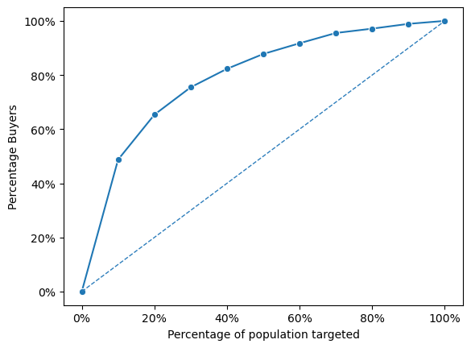

```python
# Question 2.4
# Plot gains curves for both the training and test set using the “pred_logit” variable
# (1 point)

fig = rsm.gains_plot(
    cg_organic, 'converted', 'yes', 'pred_logit',
)
```

```python
# Question 2.5
# Report the AUC of the model in both the training and test set (1 point)

lr.summary(main=False, fit=True, vif=True)
```

```
Pseudo R-squared (McFadden): 0.183
Pseudo R-squared (McFadden adjusted): 0.18
Area under the RO Curve (AUC): 0.819
Log-likelihood: -3726.455, AIC: 7478.911, BIC: 7582.29
Chi-squared: 1667.787, df(12), p.value < 0.001
Nr obs: 21,000

Variance inflation factors:

                           vif    Rsq
NumFriendRequestIgnored  1.604  0.377
NumInGameMessagesSent    1.594  0.372
NumGameDays              1.307  0.235
GameLevel                1.229  0.187
NumGameDays4Plus         1.226  0.184
TimesLostSpaceship       1.163  0.140
AcquiredSpaceship        1.152  0.132
NumFriends               1.099  0.090
NumSpaceHeroBadges       1.087  0.080
NumAdsClicked            1.049  0.047
TimesNavigator           1.043  0.041
PurchasedCoinPackLarge   1.018  0.018
```

```python
# # neural network

# scaled_data = rsm.scale_df(converted, sf=1)

# # NN1
# nn1 = rsm.model.mlp(
#     data = {'cg_organic': scaled_data},
#     rvar = 'converted',
#     evar = [
#         "GameLevel",
#         "NumGameDays",
#         "NumGameDays4Plus",
#         "NumInGameMessagesSent",
#         "NumSpaceHeroBadges",
#         "NumFriendRequestIgnored",
#         "NumFriends",
#         "AcquiredSpaceship",
#         "AcquiredIonWeapon",
#         "TimesLostSpaceship",
#         # "TimesKilled",
#         # "TimesCaptain",
#         "TimesNavigator",
#         # "PurchasedCoinPackSmall",
#         "PurchasedCoinPackLarge",
#         "NumAdsClicked",
#         # "DaysUser",
#         "UserConsole",
#         # "UserHasOldOS"
#     ],
#     hidden_layer_sizes = (8, 8),
#     mod_type = 'classification'
# )
# nn1.summary()
```

```python
# nn1.plot('pred')
```

```python
# # neural network 2

# # NN1
# nn2 = rsm.model.mlp(
#     data = {'cg_organic': cg_organic},
#     rvar = 'converted',
#     evar = [
#         "GameLevel",
#         "NumGameDays",
#         "NumGameDays4Plus",
#         "NumInGameMessagesSent",
#         "NumSpaceHeroBadges",
#         "NumFriendRequestIgnored",
#         "NumFriends",
#         "AcquiredSpaceship",
#         "AcquiredIonWeapon",
#         "TimesLostSpaceship",
#         # "TimesKilled",
#         # "TimesCaptain",
#         "TimesNavigator",
#         # "PurchasedCoinPackSmall",
#         "PurchasedCoinPackLarge",
#         "NumAdsClicked",
#         # "DaysUser",
#         "UserConsole",
#         # "UserHasOldOS"
#     ],
#     hidden_layer_sizes = (5, 5),
#     mod_type = 'classification'
# )
# nn2.summary()
```

```python
# nn2.plot('pred')
```

## PART III

```python
# You have finished building a logistic regression model to predict what kind of Space Pirates gamers were more or less likely to purchase the Zalon campaign. After debriefing Mi Haruki on the performance of the predictive model, she lays out the next steps:
# “We will test the effectiveness of the in-app ad and the predictive model by exposing a random 150,000 customers to a 2-week ad campaign and measuring their conversion to Zalon over the next 2 months. At the same time, we will randomly pick another 30,000 customers and observe their organic upgrade behavior over the same period.
# This set of customers will not be served any in-app ads.

# loading the data - this dataset must NOT be changed
cg_organic_control = pd.read_parquet("data/cg_organic_control.parquet")
rsm.md("data/cg_organic_control_description.md")
cg_organic_control.head()

# I want you to compare three groups based on this data.

# Group 1: The randomly picked 30,000 Space Pirates gamers who did not receive in-app ads during the experimental period.
# Group 2: A randomly picked 30,000 Space Pirates gamers among the 150,000 who were served in-app ads for Zalon.
# Group 3: A model-selected 30,000 Space Pirates gamers among the 120,000 (after taking out Group 2) who were served in-app ads for Zalon.

# Please report back to me how well the ads are working in terms of conversion rates and profits and by how much the model improves these metrics, all based on targeting 30,000 customers. To calculate profits, please use revenues of $14.99 from selling Zalon. The cost of serving ads to a consumer for 2 weeks is $1.50 in lost coin purchases.”
```

Creative gaming

Game telemetry dataset used for the Creative Gaming: Propensity-to-Buy Modeling case

Feature descriptions

- converted: Purchased the Zalon campain ("yes" or "no")

- GameLevel: Highest level of game achieved by the user

- NumGameDays: Number of days user played the game in last month (with or without network connection)

- NumGameDays4Plus: Number of days user played the game in last month with 4 or more total users (this implies using a network connection)

- NumInGameMessagesSent: Number of in-game messages sent to friends

- NumFriends: Number of friends to which the user is connected (necessary to crew together in multiplayer mode)

- NumFriendRequestIgnored: Number of friend requests this user has not replied to since game inception

- NumSpaceHeroBadges: Number of "Space Hero" badges, the highest distinction for gameplay in Space Pirates

- AcquiredSpaceship: Flag if the user owns a spaceship, i.e., does not have to crew on another user's or NPC's space ship ("no" or "yes")

- AcquiredIonWeapon: Flag if the user owns the powerful "ion weapon" ("no" or "yes")

- TimesLostSpaceship: The number of times the user destroyed his/her spaceship during gameplay. Spaceships need to be re-acquired if destroyed.

- TimesKilled: Number of times the user was killed during gameplay

- TimesCaptain: Number of times in last month that the user played in the role of a captain

- TimesNavigator: Number of times in last month that the user played in the role of a navigator

- PurchasedCoinPackSmall: Flag if the user purchased a small pack of Zathium in last month ("no" or "yes")

- PurchasedCoinPackLarge: Flag if the user purchased a large pack of Zathium in last month ("no" or "yes")

- NumAdsClicked: Number of in-app ads the user has clicked on

- DaysUser: Number of days since user established a user ID with Creative Gaming (for Space Pirates or previous games)

- UserConsole: Flag if the user plays Creative Gaming games on a console ("no" or "yes")

- UserHasOldOS: Flag if the user has iOS version 10 or earlier ("no" or "yes")

|  | converted | GameLevel | NumGameDays | NumGameDays4Plus | NumInGameMessagesSent | NumSpaceHeroBadges | NumFriendRequestIgnored | NumFriends | AcquiredSpaceship | AcquiredIonWeapon | TimesLostSpaceship | TimesKilled | TimesCaptain | TimesNavigator | PurchasedCoinPackSmall | PurchasedCoinPackLarge | NumAdsClicked | DaysUser | UserConsole | UserHasOldOS |
| --- | --- | --- | --- | --- | --- | --- | --- | --- | --- | --- | --- | --- | --- | --- | --- | --- | --- | --- | --- | --- |
| 110986 | no | 7 | 18 | 0 | 124 | 0 | 81 | 0 | yes | no | 8 | 0 | 0 | 4 | no | yes | 3 | 2101 | no | no |
| 155352 | no | 10 | 3 | 2 | 60 | 0 | 18 | 479 | no | no | 10 | 7 | 0 | 0 | yes | no | 7 | 1644 | yes | no |
| 115449 | no | 2 | 1 | 0 | 0 | 0 | 0 | 0 | no | no | 0 | 0 | 0 | 2 | no | no | 8 | 3197 | yes | yes |
| 138283 | no | 2 | 11 | 1 | 125 | 0 | 73 | 217 | no | no | 0 | 0 | 0 | 0 | yes | no | 6 | 913 | no | no |
| 186787 | no | 8 | 15 | 0 | 0 | 0 | 6 | 51 | yes | no | 0 | 0 | 2 | 1 | yes | no | 21 | 2009 | yes | no |

```python
# Question 3.1
# 1. Calculate the response rate and profit of group 1. The dataset containing the data for group 1 is named “data/cg_organic_control.parquet”. (2 points)
# Group 1: The randomly picked 30,000 Space Pirates gamers who did not receive in-app ads during the experimental period.
# response rate

response_rate_group1 = cg_organic_control[cg_organic_control['converted'] == 'yes'].shape[0] / cg_organic_control.shape[0]
print(response_rate_group1)

# profit
profit_group1 = (cg_organic_control[cg_organic_control['converted'] == 'yes'].shape[0] * 14.99) - (cg_organic_control.shape[0] * 1.50)
profit_group1
```

```
0.05686666666666667
```

```
-19427.06
```

```python
# The dataset needed to evaluate groups 2 and 3 is “data/cg_ad_treatment.parquet”. All customers in this dataset were exposed to advertising as part of the experiment.
# loading the data - this dataset must NOT be changed
cg_ad_treatment = pd.read_parquet("data/cg_ad_treatment.parquet")
rsm.md("data/cg_ad_treatment_description.md")

cg_ad_treatment.head()
```

Creative gaming

Game telemetry dataset used for the Creative Gaming: Propensity-to-Buy Modeling case

Feature descriptions

- converted: Purchased the Zalon campain ("yes" or "no")

- GameLevel: Highest level of game achieved by the user

- NumGameDays: Number of days user played the game in last month (with or without network connection)

- NumGameDays4Plus: Number of days user played the game in last month with 4 or more total users (this implies using a network connection)

- NumInGameMessagesSent: Number of in-game messages sent to friends

- NumFriends: Number of friends to which the user is connected (necessary to crew together in multiplayer mode)

- NumFriendRequestIgnored: Number of friend requests this user has not replied to since game inception

- NumSpaceHeroBadges: Number of "Space Hero" badges, the highest distinction for gameplay in Space Pirates

- AcquiredSpaceship: Flag if the user owns a spaceship, i.e., does not have to crew on another user's or NPC's space ship ("no" or "yes")

- AcquiredIonWeapon: Flag if the user owns the powerful "ion weapon" ("no" or "yes")

- TimesLostSpaceship: The number of times the user destroyed his/her spaceship during gameplay. Spaceships need to be re-acquired if destroyed.

- TimesKilled: Number of times the user was killed during gameplay

- TimesCaptain: Number of times in last month that the user played in the role of a captain

- TimesNavigator: Number of times in last month that the user played in the role of a navigator

- PurchasedCoinPackSmall: Flag if the user purchased a small pack of Zathium in last month ("no" or "yes")

- PurchasedCoinPackLarge: Flag if the user purchased a large pack of Zathium in last month ("no" or "yes")

- NumAdsClicked: Number of in-app ads the user has clicked on

- DaysUser: Number of days since user established a user ID with Creative Gaming (for Space Pirates or previous games)

- UserConsole: Flag if the user plays Creative Gaming games on a console ("no" or "yes")

- UserHasOldOS: Flag if the user has iOS version 10 or earlier ("no" or "yes")

- rnd_30k: Dummy variable that randomly selects 30K customers (1) and the remaining 90K (0)

|  | converted | GameLevel | NumGameDays | NumGameDays4Plus | NumInGameMessagesSent | NumSpaceHeroBadges | NumFriendRequestIgnored | NumFriends | AcquiredSpaceship | AcquiredIonWeapon | ... | TimesKilled | TimesCaptain | TimesNavigator | PurchasedCoinPackSmall | PurchasedCoinPackLarge | NumAdsClicked | DaysUser | UserConsole | UserHasOldOS | rnd_30k |
| --- | --- | --- | --- | --- | --- | --- | --- | --- | --- | --- | --- | --- | --- | --- | --- | --- | --- | --- | --- | --- | --- |
| 109438 | no | 6 | 16 | 0 | 0 | 0 | 0 | 0 | yes | no | ... | 0 | 0 | 0 | no | no | 11 | 1827 | no | no | 0 |
| 49977 | no | 2 | 8 | 0 | 0 | 0 | 5 | 4 | no | no | ... | 0 | 8 | 0 | yes | no | 3 | 1889 | no | yes | 1 |
| 99506 | no | 6 | 1 | 0 | 0 | 0 | 0 | 0 | no | no | ... | 0 | 0 | 0 | no | yes | 2 | 1948 | yes | no | 0 |
| 411831 | yes | 7 | 16 | 0 | 102 | 1 | 0 | 194 | no | no | ... | 0 | 0 | 0 | yes | yes | 21 | 3409 | yes | yes | 0 |
| 82610 | no | 10 | 1 | 1 | 233 | 0 | 23 | 0 | no | no | ... | 0 | 5 | 0 | no | yes | 4 | 2922 | yes | no | 0 |

5 rows × 21 columns

```python
# Question 3.2
# 2. Calculate the response rate and profit of group 2. Set a filter “rnd_30k == 1” to select the 30,000 customers from the 150,000 rows in “cg_ad_treatment”. (2 points)

group2 = cg_ad_treatment[cg_ad_treatment['rnd_30k'] == 1]
group2

# response rate
response_rate_group2 = group2[group2['converted'] == 'yes'].shape[0] / group2.shape[0]
print(response_rate_group2)

# profit
profit_group2 = (group2[group2['converted'] == 'yes'].shape[0] * 14.99) - (group2.shape[0] * 1.50)
profit_group2
# # response rate
# response_rate_group2 = cg_ad_treatment[cg_ad_treatment['converted'] == 'yes'].shape[0] / cg_ad_treatment.shape[0]
# response_rate_group2

# # profit
# profit_group2 = (cg_ad_treatment[cg_ad_treatment['converted'] == 'yes'].shape[0] * 14.99) - (cg_ad_treatment.shape[0] * 1.50)
# profit_group2
```

```
0.13043333333333335
```

```
13655.870000000003
```

```python
# Question 3.3
# 3. Calculate the response rate and profit of group 3. To do this please:
# a. Use the logistic regression model you trained in Part II to predict the
# probability of purchasing the Zalon campaign (i.e., score) all 150,000 gamers in the “cg_ad_treatment”. (1 point)

# prediction
cg_ad_treatment['pred_logit'] = lr.predict(cg_ad_treatment)['prediction']
cg_ad_treatment
```

|  | converted | GameLevel | NumGameDays | NumGameDays4Plus | NumInGameMessagesSent | NumSpaceHeroBadges | NumFriendRequestIgnored | NumFriends | AcquiredSpaceship | AcquiredIonWeapon | ... | TimesCaptain | TimesNavigator | PurchasedCoinPackSmall | PurchasedCoinPackLarge | NumAdsClicked | DaysUser | UserConsole | UserHasOldOS | rnd_30k | pred_logit |
| --- | --- | --- | --- | --- | --- | --- | --- | --- | --- | --- | --- | --- | --- | --- | --- | --- | --- | --- | --- | --- | --- |
| 109438 | no | 6 | 16 | 0 | 0 | 0 | 0 | 0 | yes | no | ... | 0 | 0 | no | no | 11 | 1827 | no | no | 0 | 0.065233 |
| 49977 | no | 2 | 8 | 0 | 0 | 0 | 5 | 4 | no | no | ... | 8 | 0 | yes | no | 3 | 1889 | no | yes | 1 | 0.015476 |
| 99506 | no | 6 | 1 | 0 | 0 | 0 | 0 | 0 | no | no | ... | 0 | 0 | no | yes | 2 | 1948 | yes | no | 0 | 0.023676 |
| 411831 | yes | 7 | 16 | 0 | 102 | 1 | 0 | 194 | no | no | ... | 0 | 0 | yes | yes | 21 | 3409 | yes | yes | 0 | 0.142359 |
| 82610 | no | 10 | 1 | 1 | 233 | 0 | 23 | 0 | no | no | ... | 5 | 0 | no | yes | 4 | 2922 | yes | no | 0 | 0.036923 |
| ... | ... | ... | ... | ... | ... | ... | ... | ... | ... | ... | ... | ... | ... | ... | ... | ... | ... | ... | ... | ... | ... |
| 172637 | no | 6 | 8 | 0 | 115 | 0 | 13 | 0 | yes | no | ... | 0 | 4 | no | no | 11 | 2343 | yes | no | 1 | 0.038742 |
| 87840 | no | 7 | 19 | 0 | 0 | 0 | 0 | 0 | no | no | ... | 0 | 0 | no | no | 1 | 3166 | yes | no | 0 | 0.036811 |
| 143309 | no | 1 | 5 | 0 | 207 | 0 | 37 | 10 | yes | no | ... | 3 | 0 | yes | yes | 5 | 2619 | yes | no | 0 | 0.013678 |
| 159361 | no | 7 | 19 | 1 | 0 | 0 | 88 | 0 | no | no | ... | 1 | 4 | no | no | 9 | 2343 | no | no | 0 | 0.011715 |
| 208052 | no | 5 | 11 | 2 | 50 | 6 | 55 | 333 | no | no | ... | 0 | 1 | yes | no | 0 | 2557 | yes | yes | 0 | 0.200702 |

150000 rows × 22 columns

```python
# b. Select the 30,000 customers with best predictions (scores) that are not part of group 2. Use only these 30,000 to compute conversion rates and profits of group 3. (1 point)

# selecting the 30,000 customers with best predictions that are not part of group 2

group3 = cg_ad_treatment[cg_ad_treatment['rnd_30k'] == 0].sort_values('pred_logit', ascending=False).head(30000)
# count the raws in group 3
# print(group3.shape[0])

# response rate
response_rate_group3 = group3[group3['converted'] == 'yes'].shape[0] / group3.shape[0]
print(response_rate_group3)

# profit
profit_group3 = (group3[group3['converted'] == 'yes'].shape[0] * 14.99) - (group3.shape[0] * 1.50)
profit_group3
```

```
0.21566666666666667
```

```
51985.3
```

```python
# Question 3.4

# Answer Mi Haruki’s question: “Please report back to me how well the ads are working in terms of conversion rates and profits and by how much the model improves these metrics, all based on targeting 30,000 customers.” (2 points)

# conversion rates
conversion_rates = pd.DataFrame({
    'group': ['group1', 'group2', 'group3'],
    'response_rate': [response_rate_group1, response_rate_group2, response_rate_group3],
    'profit': [profit_group1, profit_group2, profit_group3]
})

conversion_rates
```

|  | group | response_rate | profit |
| --- | --- | --- | --- |
| 0 | group1 | 0.056867 | -19427.06 |
| 1 | group2 | 0.130433 | 13655.87 |
| 2 | group3 | 0.215667 | 51985.30 |

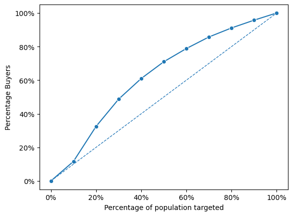

```python
# Question 3.5
# Plot the gains curve for all customers that are not in group 2 (i.e., rnd_30k == 0). Also report the AUC of the for this set of customers. Compare the gains curve and AUC to the ones you calculated in Part II.4 and II.5. Why are they different? (2 points)

fig = rsm.gains_plot(
    cg_ad_treatment[cg_ad_treatment['rnd_30k'] == 0], 'converted', 'yes', 'pred_logit',
)

# show the plot
plt.show()
```

```python
from sklearn.metrics import roc_auc_score

# Filter the DataFrame for 'rnd_30k' == 0 and extract the relevant columns
filtered_data = cg_ad_treatment[cg_ad_treatment['rnd_30k'] == 0]
y_true = filtered_data['converted'] == "yes"  # Assuming 'converted' contains "yes" for positive cases
y_scores = filtered_data['pred_logit']

# Calculate AUC
auc_score = roc_auc_score(y_true, y_scores)

# Print the calculated AUC
print("AUC:", auc_score)
```

```
AUC: 0.6454697796738411
```

```python
# Question 3.6
# 6. Why would CG have collecting data for group 1 (cg_organic_control) given that they already had data on organic conversions from the cg_organic data? (2 points)
```

CG collected data for group 1 (cg_organic_control) despite having data on organic conversions from the cg_organic data to establish a baseline for comparison. This allows for the accurate assessment of the impact of any interventions by comparing changes in the control group with those in experimental groups, ensuring any observed differences in organic conversions can be attributed directly to the interventions.

## PART IV

```python
# 1. Retrain the logistic regression model from Part II on the random sample of 30K customers in “cg_ad_treatment” and generate predictions
# for all 150,000 customers. Assign the predictions to a new variable “pred_logit_ad”. (2 points)
## loading the data - this dataset must NOT be changed
cg_ad_treatment = pd.read_parquet("data/cg_ad_treatment.parquet")
rsm.md("data/cg_ad_treatment_description.md")
```

Creative gaming

Game telemetry dataset used for the Creative Gaming: Propensity-to-Buy Modeling case

Feature descriptions

- converted: Purchased the Zalon campain ("yes" or "no")

- GameLevel: Highest level of game achieved by the user

- NumGameDays: Number of days user played the game in last month (with or without network connection)

- NumGameDays4Plus: Number of days user played the game in last month with 4 or more total users (this implies using a network connection)

- NumInGameMessagesSent: Number of in-game messages sent to friends

- NumFriends: Number of friends to which the user is connected (necessary to crew together in multiplayer mode)

- NumFriendRequestIgnored: Number of friend requests this user has not replied to since game inception

- NumSpaceHeroBadges: Number of "Space Hero" badges, the highest distinction for gameplay in Space Pirates

- AcquiredSpaceship: Flag if the user owns a spaceship, i.e., does not have to crew on another user's or NPC's space ship ("no" or "yes")

- AcquiredIonWeapon: Flag if the user owns the powerful "ion weapon" ("no" or "yes")

- TimesLostSpaceship: The number of times the user destroyed his/her spaceship during gameplay. Spaceships need to be re-acquired if destroyed.

- TimesKilled: Number of times the user was killed during gameplay

- TimesCaptain: Number of times in last month that the user played in the role of a captain

- TimesNavigator: Number of times in last month that the user played in the role of a navigator

- PurchasedCoinPackSmall: Flag if the user purchased a small pack of Zathium in last month ("no" or "yes")

- PurchasedCoinPackLarge: Flag if the user purchased a large pack of Zathium in last month ("no" or "yes")

- NumAdsClicked: Number of in-app ads the user has clicked on

- DaysUser: Number of days since user established a user ID with Creative Gaming (for Space Pirates or previous games)

- UserConsole: Flag if the user plays Creative Gaming games on a console ("no" or "yes")

- UserHasOldOS: Flag if the user has iOS version 10 or earlier ("no" or "yes")

- rnd_30k: Dummy variable that randomly selects 30K customers (1) and the remaining 90K (0)

```python
# random sample of 30k customers in “cg_ad_treatment”
rnd_30 = cg_ad_treatment.query("rnd_30k == 1")
rnd_30.head()
```

|  | converted | GameLevel | NumGameDays | NumGameDays4Plus | NumInGameMessagesSent | NumSpaceHeroBadges | NumFriendRequestIgnored | NumFriends | AcquiredSpaceship | AcquiredIonWeapon | ... | TimesKilled | TimesCaptain | TimesNavigator | PurchasedCoinPackSmall | PurchasedCoinPackLarge | NumAdsClicked | DaysUser | UserConsole | UserHasOldOS | rnd_30k |
| --- | --- | --- | --- | --- | --- | --- | --- | --- | --- | --- | --- | --- | --- | --- | --- | --- | --- | --- | --- | --- | --- |
| 49977 | no | 2 | 8 | 0 | 0 | 0 | 5 | 4 | no | no | ... | 0 | 8 | 0 | yes | no | 3 | 1889 | no | yes | 1 |
| 146436 | no | 5 | 15 | 0 | 179 | 0 | 50 | 362 | yes | no | ... | 0 | 4 | 4 | no | no | 2 | 1308 | yes | no | 1 |
| 85884 | no | 7 | 7 | 0 | 267 | 0 | 64 | 0 | no | no | ... | 0 | 0 | 0 | no | yes | 1 | 3562 | yes | no | 1 |
| 1668 | no | 4 | 4 | 0 | 36 | 0 | 0 | 0 | no | no | ... | 0 | 0 | 0 | no | no | 2 | 2922 | yes | no | 1 |
| 192886 | no | 8 | 17 | 0 | 222 | 10 | 63 | 20 | yes | no | ... | 0 | 9 | 6 | yes | no | 4 | 2192 | yes | no | 1 |

5 rows × 21 columns

```python
# retaining the model from Part 2 and applying it to the random sample of 30k customers in “cg_ad_treatment”

lr_ad = rsm.model.logistic(
    data = rnd_30,
    rvar = 'converted',
    lev = 'yes',
    evar=[
        "GameLevel",
        "NumGameDays",
        "NumGameDays4Plus",
        "NumInGameMessagesSent",
        "NumSpaceHeroBadges",
        "NumFriendRequestIgnored",
        "NumFriends",
        "AcquiredSpaceship",
        "TimesLostSpaceship",
        "TimesNavigator",
        "PurchasedCoinPackLarge",
        "NumAdsClicked",
    ],
)
lr_ad.summary(
    vif=True
)
```

```
Logistic regression (GLM)
Data                 : Not provided
Response variable    : converted
Level                : yes
Explanatory variables: GameLevel, NumGameDays, NumGameDays4Plus, NumInGameMessagesSent, NumSpaceHeroBadges, NumFriendRequestIgnored, NumFriends, AcquiredSpaceship, TimesLostSpaceship, TimesNavigator, PurchasedCoinPackLarge, NumAdsClicked
Null hyp.: There is no effect of x on converted
Alt. hyp.: There is an effect of x on converted

                                OR     OR%  coefficient  std.error  z.value p.value
Intercept                    0.029  -97.1%        -3.55      0.061  -58.652  < .001  ***
AcquiredSpaceship[yes]       1.095    9.5%         0.09      0.041    2.221   0.026    *
PurchasedCoinPackLarge[yes]  1.180   18.0%         0.17      0.040    4.102  < .001  ***
GameLevel                    1.054    5.4%         0.05      0.007    7.062  < .001  ***
NumGameDays                  1.015    1.5%         0.02      0.003    5.176  < .001  ***
NumGameDays4Plus             1.011    1.1%         0.01      0.005    2.004   0.045    *
NumInGameMessagesSent        1.000   -0.0%        -0.00      0.000   -0.914   0.361
NumSpaceHeroBadges           1.022    2.2%         0.02      0.008    2.706   0.007   **
NumFriendRequestIgnored      1.000    0.0%         0.00      0.001    0.081   0.936
NumFriends                   1.002    0.2%         0.00      0.000   11.084  < .001  ***
TimesLostSpaceship           0.994   -0.6%        -0.01      0.002   -3.156   0.002   **
TimesNavigator               0.999   -0.1%        -0.00      0.002   -0.285   0.776
NumAdsClicked                1.093    9.3%         0.09      0.002   39.689  < .001  ***

Signif. codes:  0 '***' 0.001 '**' 0.01 '*' 0.05 '.' 0.1 ' ' 1

Pseudo R-squared (McFadden): 0.093
Pseudo R-squared (McFadden adjusted): 0.092
Area under the RO Curve (AUC): 0.706
Log-likelihood: -10530.643, AIC: 21087.286, BIC: 21195.302
Chi-squared: 2171.292, df(12), p.value < 0.001
Nr obs: 30,000

Variance inflation factors:

                           vif    Rsq
NumFriendRequestIgnored  1.606  0.377
NumInGameMessagesSent    1.585  0.369
NumGameDays              1.334  0.250
GameLevel                1.261  0.207
NumGameDays4Plus         1.249  0.200
AcquiredSpaceship        1.160  0.138
NumSpaceHeroBadges       1.133  0.117
NumFriends               1.117  0.105
TimesLostSpaceship       1.103  0.093
TimesNavigator           1.052  0.049
NumAdsClicked            1.029  0.028
PurchasedCoinPackLarge   1.018  0.018
```

```python
# predictions for all 150,000 customers
cg_ad_treatment['pred_logit_ad'] = lr_ad.predict(cg_ad_treatment)['prediction']
cg_ad_treatment.head()
```

|  | converted | GameLevel | NumGameDays | NumGameDays4Plus | NumInGameMessagesSent | NumSpaceHeroBadges | NumFriendRequestIgnored | NumFriends | AcquiredSpaceship | AcquiredIonWeapon | ... | TimesCaptain | TimesNavigator | PurchasedCoinPackSmall | PurchasedCoinPackLarge | NumAdsClicked | DaysUser | UserConsole | UserHasOldOS | rnd_30k | pred_logit_ad |
| --- | --- | --- | --- | --- | --- | --- | --- | --- | --- | --- | --- | --- | --- | --- | --- | --- | --- | --- | --- | --- | --- |
| 109438 | no | 6 | 16 | 0 | 0 | 0 | 0 | 0 | yes | no | ... | 0 | 0 | no | no | 11 | 1827 | no | no | 0 | 0.127595 |
| 49977 | no | 2 | 8 | 0 | 0 | 0 | 5 | 4 | no | no | ... | 8 | 0 | yes | no | 3 | 1889 | no | yes | 1 | 0.045121 |
| 99506 | no | 6 | 1 | 0 | 0 | 0 | 0 | 0 | no | no | ... | 0 | 0 | no | yes | 2 | 1948 | yes | no | 0 | 0.053253 |
| 411831 | yes | 7 | 16 | 0 | 102 | 1 | 0 | 194 | no | no | ... | 0 | 0 | yes | yes | 21 | 3409 | yes | yes | 0 | 0.366278 |
| 82610 | no | 10 | 1 | 1 | 233 | 0 | 23 | 0 | no | no | ... | 5 | 0 | no | yes | 4 | 2922 | yes | no | 0 | 0.073089 |

5 rows × 22 columns

```python
cg_ad_treatment.columns
```

```
Index(['converted', 'GameLevel', 'NumGameDays', 'NumGameDays4Plus',
       'NumInGameMessagesSent', 'NumSpaceHeroBadges',
       'NumFriendRequestIgnored', 'NumFriends', 'AcquiredSpaceship',
       'AcquiredIonWeapon', 'TimesLostSpaceship', 'TimesKilled',
       'TimesCaptain', 'TimesNavigator', 'PurchasedCoinPackSmall',
       'PurchasedCoinPackLarge', 'NumAdsClicked', 'DaysUser', 'UserConsole',
       'UserHasOldOS', 'rnd_30k', 'pred_logit_ad'],
      dtype='object')
```

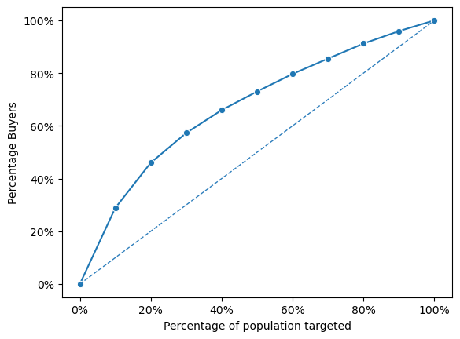

```python
# 2. Compare the performance of the original “organic” model from Part II
# and the new “ad” model across the 120,000K customers that are not in group 2. Use gains curves and AUC to make the comparison. What do you find? (2 points)

fig = rsm.gains_plot(
    df=cg_ad_treatment,
    rvar='converted',
    lev='yes',
    pred='pred_logit_ad'
)
```

```python
# AUC for lr_ad model

data = cg_ad_treatment
y = data['converted'] == 'yes'
y_score = data['pred_logit_ad']

roc_auc_score(y, y_score)
```

```
0.7041568279718005
```

```python
# 3. Calculate the profit improvement of using the “ad” model instead of the “organic” model to
# target the best 30,000 customers in the “cg_ad_treatment” data that are not in “rnd_30k == 1”. (2 points)

# selecting the 30,000 customers with best predictions that are not part of group 2
new_group3 = cg_ad_treatment[cg_ad_treatment['rnd_30k'] == 0].sort_values('pred_logit_ad', ascending=False).head(30000)

# profit
profit_new_group3 = (new_group3[new_group3['converted'] == 'yes'].shape[0] * 14.99) - (new_group3.shape[0] * 1.50)
profit_new_group3
```

```
78247.78
```

```python
# permutation importance of ad model

lr_ad.plot('vimp')
```

[output not shown]